# Population structure from RAD loci with ANGSD

J. Ignacio Lucas Lledó

2025-03-26

Here I want to determine the population structure of *Crepidostomum* samples using SNPs from mapping to RAD loci. Only samples from the Arctic region are available, because the few Alpine samples sequenced do not have enough data. Because the reference used are *de novo* assembled RAD loci, distances among SNPs are very short within a locus and completely unknown among loci. Thus, instead of using `ngsLD` to prune sites affected by linkage disequilibrium, I can simply select one SNP from each locus.

The following script was run in Garnatxa to generate genotype likelihoods:

```bash
#!/bin/bash
#SBATCH --job-name=angsd1
#SBATCH --output=angsd1.log
#SBATCH --nodes=1
#SBATCH --ntasks=1
#SBATCH --cpus-per-task=8
#SBATCH --mem=15G
#SBATCH --qos=medium
#SBATCH --time=7-00:00:00

module load anaconda
mamba activate bio
module load angsd

cd /scr/joiglu/crepi/2024-10-05

BAM=../2024-10-04/BAM
ASM=../2024-10-04/radloci.fa
EXCLUDE=../2024-10-04/BadGuys.txt
GOODLOCI=../2024-10-04/GoodLoci.txt

if [ ! -e ARCTIC.list ]; then
   ls -1 $BAM/*.bam | grep -E "L|S" | grep -v -F -f $EXCLUDE > ARCTIC.list
fi
if [ ! -d Likes1 ]; then mkdir Likes1; fi
for REGION in ARCTIC; do
   MININD=60
   if [ ! -e Likes1/${REGION}.beagle.gz ]; then
      angsd -bam ${REGION}.list \
            -ref $ASM \
            -rf $GOODLOCI \
            -out Likes1/${REGION} \
            -only_proper_pairs 1 \
            -baq 1 \
            -setMinDepth 20 \
            -minInd $MININD \
            -GL 1 \
            -doGlf 2 \
            -doIBS 1 \
            -doCounts 1 \
            -doCov 1 \
            -makeMatrix 1 \
            -doMajorMinor 1 \
            -doMaf 1 \
            -SNP_pval 1e-6 \
            -minMapQ 30 \
            -minQ 20 \
            -minMaf 0.05 \
            -nThreads 8 \
            1> Likes1/${REGION}.angsd.log \
            2> Likes1/${REGION}.angsd.err &
   fi
done
wait
```

## Selection of one SNP per RAD locus

```r
if (! file.exists('Sites/ARCTIC_snp.sites')){
   library(readr)
   MAF <- read_tsv('Likes1/ARCTIC.mafs.gz', show_col_types = FALSE)
   Sites <- do.call(
      rbind,
      lapply(split(MAF, MAF$chromo),
             function(x){
                x2 <- x[x$nInd == max(x$nInd),]
                return(x2[sample(dim(x2)[1], 1), c('chromo', 'position')])
             })
   )
   write.table(Sites, file = 'Sites/ARCTIC_snp.sites',
               quote = FALSE, sep = '\t', row.names = FALSE,
               col.names = FALSE)
}
```

## Genotype likelihoods of only selected sites

The following script was run in Garnatxa:

```bash
#!/bin/bash
#SBATCH --job-name=angsd2
#SBATCH --output=angsd2.log
#SBATCH --nodes=1
#SBATCH --ntasks=1
#SBATCH --cpus-per-task=8
#SBATCH --mem=13G
#SBATCH --qos=medium
#SBATCH --time=7-00:00:00

module load anaconda
conda deactivate
mamba activate bio
module load angsd

cd /scr/joiglu/crepi/results/2024-10-05

BAM=../2024-10-04/BAM
ASM=../2024-10-04/radloci.fa

if [ ! -d Likes2 ]; then mkdir Likes2; fi
for REGION in ARCTIC; do
   if [ ! -e Sites/${REGION}_snp.sites.bin ]; then
      sed -i 's/:/\t/' Sites/${REGION}_snp.sites
      angsd sites index Sites/${REGION}_snp.sites 2> Sites/${REGION}_snp.sites.log
   fi
   if [ ! -e Sites/${REGION}_contigs.txt ]; then
      cut -f 1 Sites/${REGION}_snp.sites | sort | uniq > Sites/${REGION}_contigs.txt
   fi
   if [ ! -e Likes2/${REGION}.beagle.gz ]; then
      angsd -bam ${REGION}.list \
            -ref $ASM \
            -sites Sites/${REGION}_snp.sites \
            -rf Sites/${REGION}_contigs.txt \
            -out Likes2/${REGION} \
            -only_proper_pairs 1 \
            -baq 1 \
            -setMinDepthInd 2 \
            -GL 1 \
            -doGlf 2 \
            -doIBS 1 \
            -doCounts 1 \
            -doCov 1 \
            -makeMatrix 1 \
            -doMajorMinor 1 \
            -doMaf 1 \
            -SNP_pval 2e-10 \
            -minMapQ 30 \
            -minQ 20 \
            -minMaf 0.05 \
            -nThreads 8 \
            1> Likes2/${REGION}.angsd.log \
            2> Likes2/${REGION}.angsd.err
   fi
done

if [ ! -d PCangsd ]; then mkdir PCangsd; fi
for REGION in ARCTIC; do
   if [ ! -e PCangsd/${REGION}.cov ]; then
      pcangsd --beagle Likes2/${REGION}.beagle.gz \
              --out PCangsd/${REGION} \
              --threads 8 \
              1> PCangsd/${REGION}.stdout \
              2> PCangsd/${REGION}.stderr &
   fi
done
wait

if [ ! -d NGSadmix ]; then mkdir NGSadmix; fi
for REGION in ARCTIC; do
   for K in 2 3 4 5 6; do
      if [ ! -e NGSadmix/${REGION}.K${K}.qopt ]; then
         /home/joiglu/software/NGSTOOLS/angsd/misc/NGSadmix -likes Likes2/${REGION}.beagle.gz \
                  -K $K \
                  -P 8 \
                  -outfiles NGSadmix/${REGION}.K${K} \
                  -minMaf 0.05 \
                  -maxiter 8000 \
                  1> NGSadmix/${REGION}.NGSadmix.K${K}.log \
                  2> NGSadmix/${REGION}.NGSadmix.K${K}.err &
      fi
   done
   wait
done

for REGION in ARCTIC; do
   for K in 2 3 4 5 6; do
      if [ ! -e NGSadmix/${REGION}.K${K}.eval ]; then
         evalAdmix -beagle Likes2/$REGION.beagle.gz \
                   -fname NGSadmix/$REGION.K$K.fopt.gz \
                   -qname NGSadmix/$REGION.K$K.qopt \
                   -o NGSadmix/$REGION.K$K.eval \
                   1> NGSadmix/$REGION.K$K.eval.log \
                   2> NGSadmix/$REGION.K$K.eval.err &
      fi
   done
   wait
done
```

Actually, `pcangsd` didn’t run in Garnatxa, and I run it here. No need to repeat the code.

```bash
grep 'Number of sites retained after filtering:' Likes2/ARCTIC.angsd.err
```

```
##  -> Number of sites retained after filtering: 39698
```

## NGSadmix results

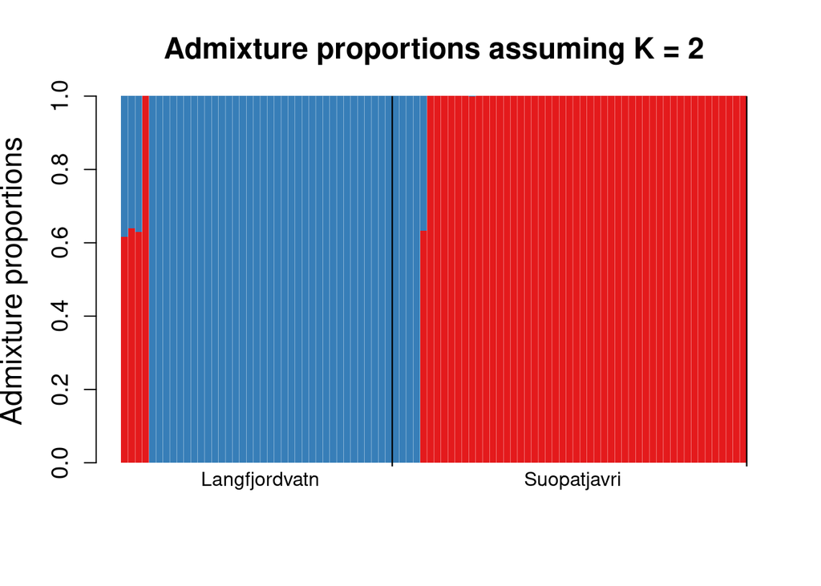

```r
source('/data/joiglu/bin/evalAdmix/visFuns.R')
MetaData <- read.table('../../data/IDs/Crepido_fish_IDs_all_data_2021Dec.txt')
IndNames <- gsub('(../2024-10-04/BAM/|.bam)', '',
                 scan('ARCTIC.list', what = 'character', quiet = TRUE))
MetaData <- MetaData[MetaData$P_code %in% IndNames, ]
row.names(MetaData) <- MetaData$P_code
Lake <- MetaData[IndNames, 'Lake']
QK2 <- read.table('NGSadmix/ARCTIC.K2.qopt')
QK3 <- read.table('NGSadmix/ARCTIC.K3.qopt')
QK4 <- read.table('NGSadmix/ARCTIC.K4.qopt')
QK5 <- read.table('NGSadmix/ARCTIC.K5.qopt')
QK6 <- read.table('NGSadmix/ARCTIC.K6.qopt')
ord <- orderInds(pop = Lake, q = QK4)

plotAdmix(QK2, pop = Lake, ord = ord)
```

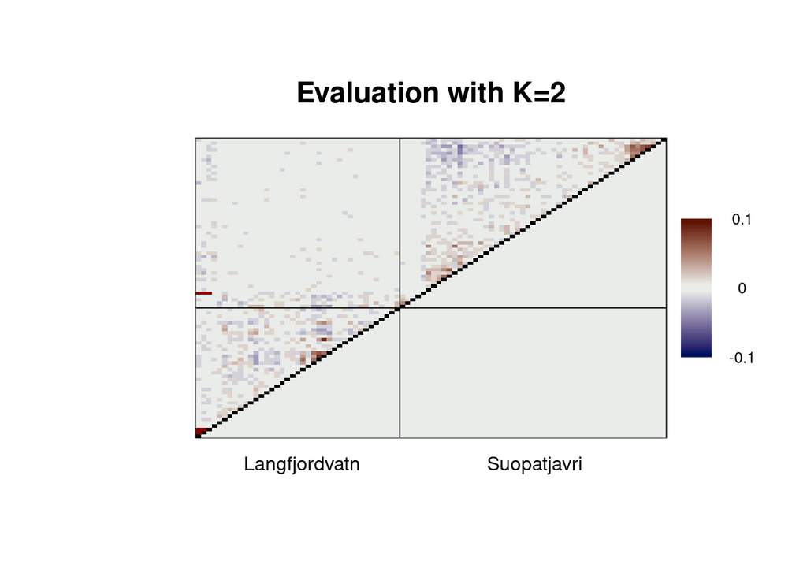

```r
r <- as.matrix(read.table('NGSadmix/ARCTIC.K2.eval'))
plotCorRes(cor_mat = r, pop = Lake, ord = ord,
           title = 'Evaluation with K=2', min_z = -0.1,
           max_z = 0.1, cex.lab = 1,
           pop_labels = c(FALSE, TRUE), cex.legend = 0.8)
```

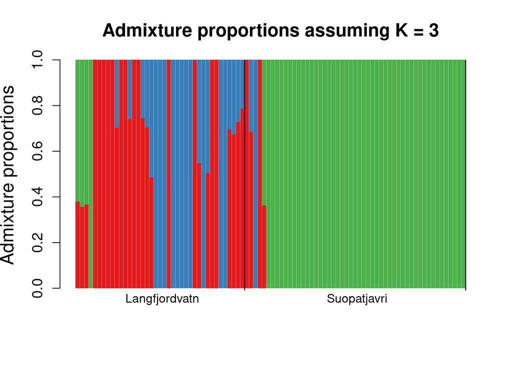

```r
plotAdmix(QK3, pop = Lake, ord = ord)
```

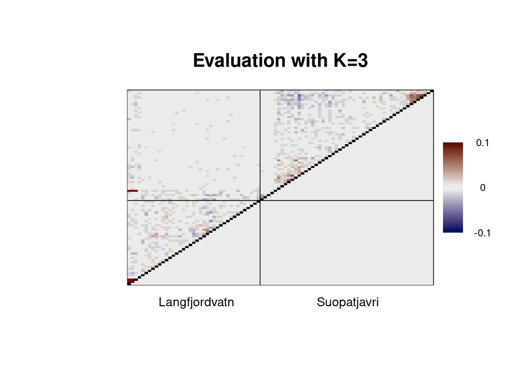

```r
r <- as.matrix(read.table('NGSadmix/ARCTIC.K3.eval'))
plotCorRes(cor_mat = r, pop = Lake, ord = ord,
           title = 'Evaluation with K=3', min_z = -0.1,
           max_z = 0.1, cex.lab = 1,
           pop_labels = c(FALSE, TRUE), cex.legend = 0.8)
```

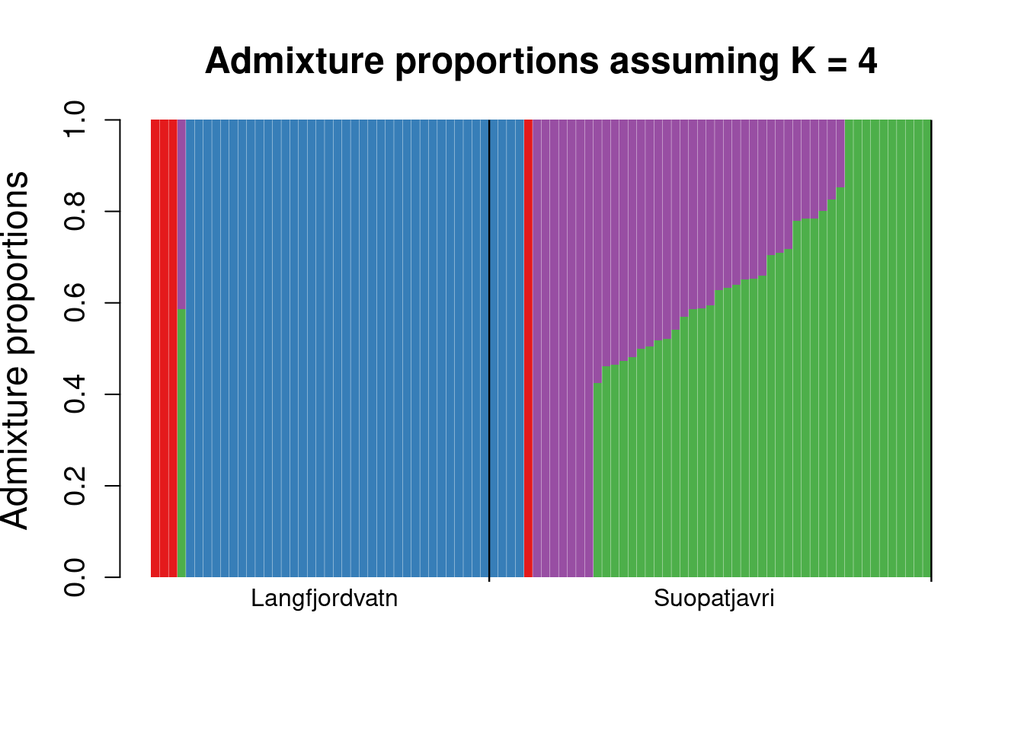

```r
plotAdmix(QK4, pop = Lake, ord = ord)
```

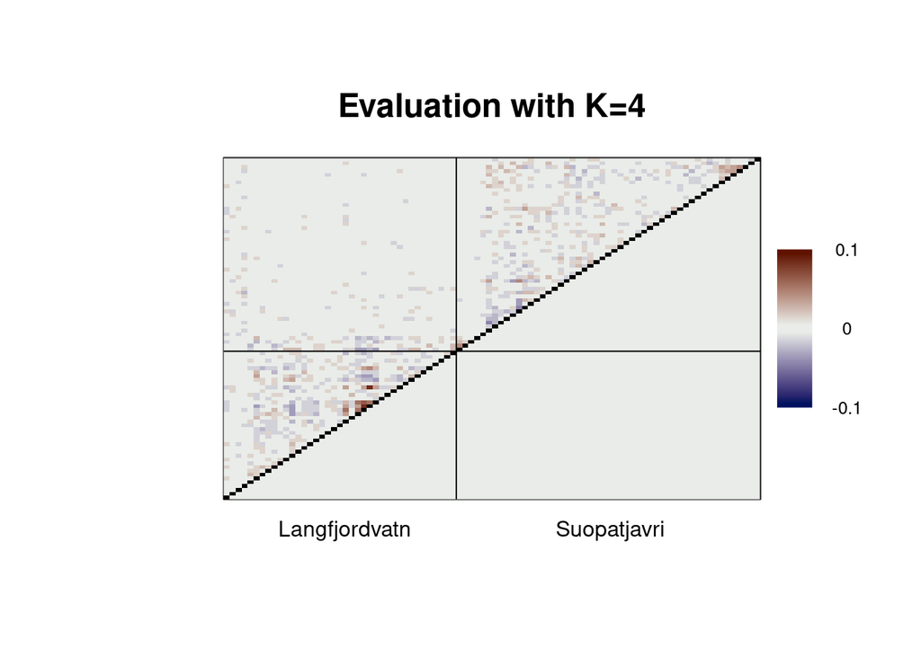

```r
r <- as.matrix(read.table('NGSadmix/ARCTIC.K4.eval'))
plotCorRes(cor_mat = r, pop = Lake, ord = ord,
           title = 'Evaluation with K=4', min_z = -0.1,
           max_z = 0.1, cex.lab = 1,
           pop_labels = c(FALSE, TRUE), cex.legend = 0.8)
```

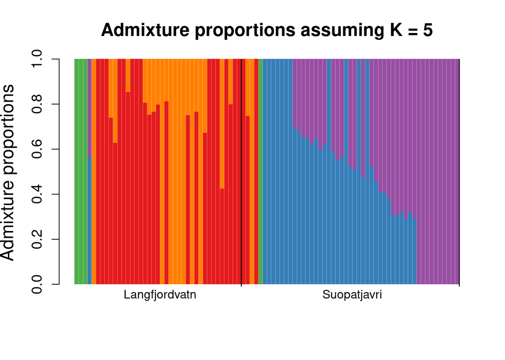

```r
plotAdmix(QK5, pop = Lake, ord = ord)
```

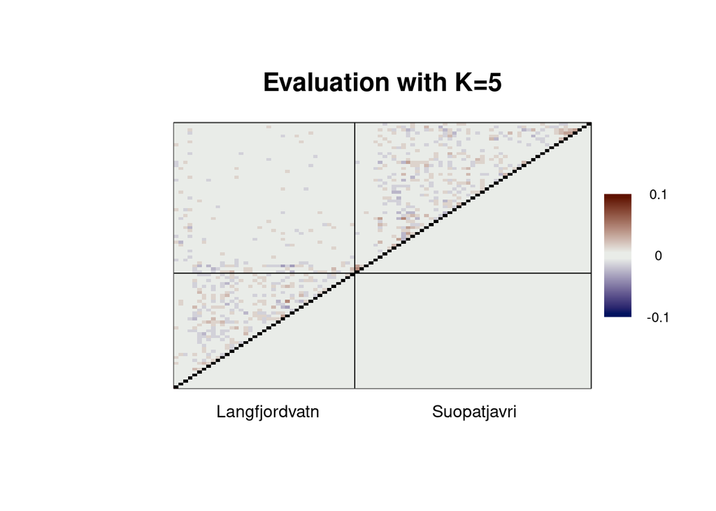

```r
r <- as.matrix(read.table('NGSadmix/ARCTIC.K5.eval'))
plotCorRes(cor_mat = r, pop = Lake, ord = ord,
           title = 'Evaluation with K=5', min_z = -0.1,
           max_z = 0.1, cex.lab = 1,
           pop_labels = c(FALSE, TRUE), cex.legend = 0.8)
```

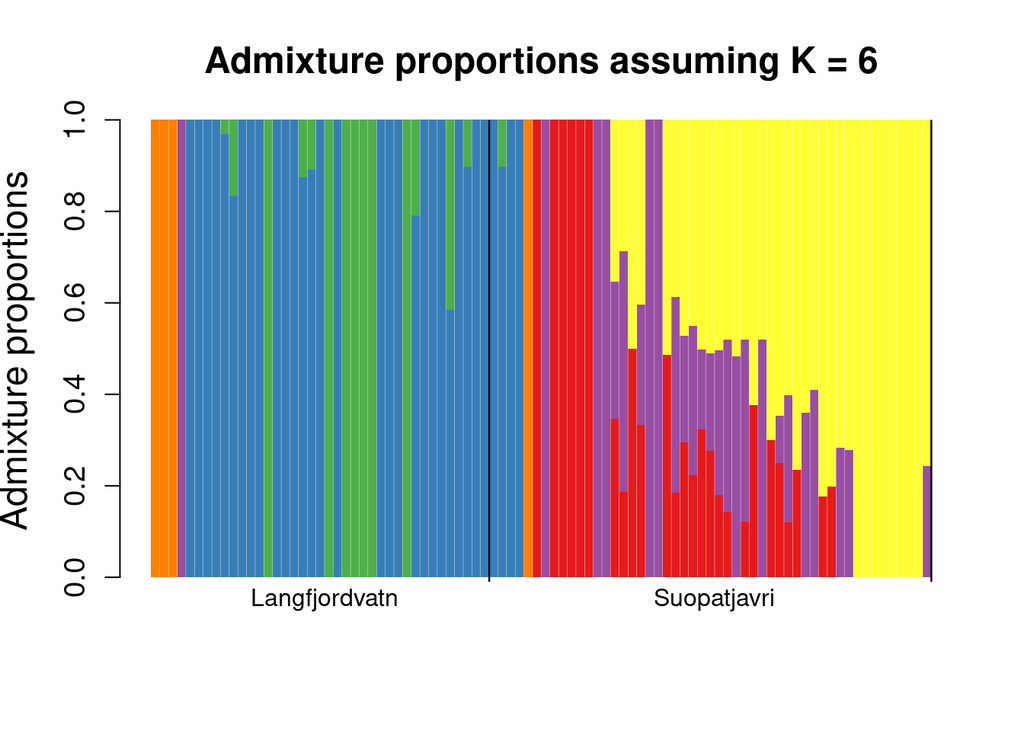

```r
plotAdmix(QK6, pop = Lake, ord = ord)
```

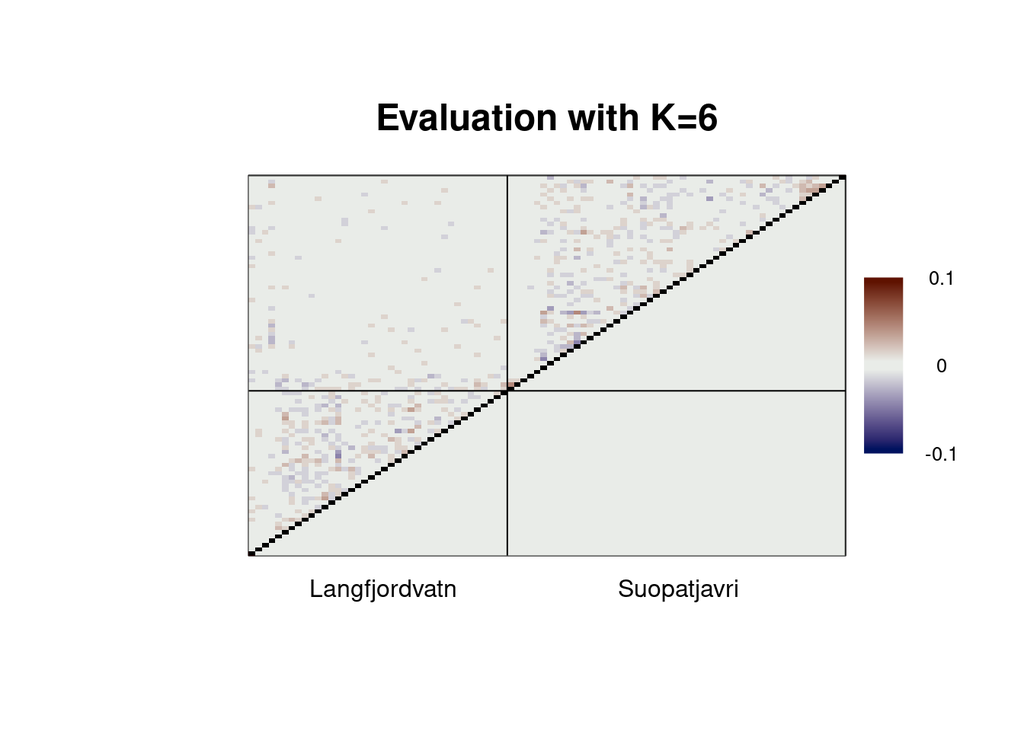

```r
r <- as.matrix(read.table('NGSadmix/ARCTIC.K6.eval'))
plotCorRes(cor_mat = r, pop = Lake, ord = ord,
           title = 'Evaluation with K=6', min_z = -0.1,
           max_z = 0.1, cex.lab = 1,
           pop_labels = c(FALSE, TRUE), cex.legend = 0.8)
```

## Results from PCangsd

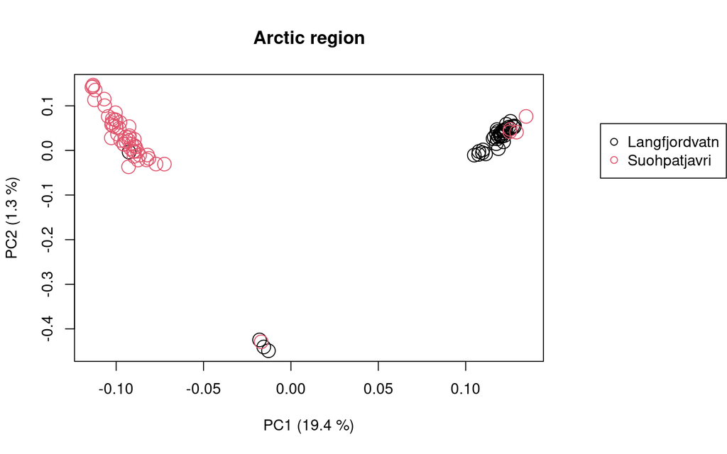

```r
Lake <- as.factor(Lake)
cov <- as.matrix(read.table('PCangsd/ARCTIC.cov'))
e   <- eigen(cov)
layout(matrix(1:2, ncol = 2), width = c(4, 1), height = c(1, 1))
plot(e$vectors[, c(1, 2)], col = Lake, pch = 1, cex = 2,
     xlab = sprintf('PC1 (%.1f %%)', 100 * e$values[1] / sum(e$values)),
     ylab = sprintf('PC2 (%.1f %%)', 100 * e$values[2] / sum(e$values)),
     main = 'Arctic region')
par(mar = c(0, 0, 4.1, 0))
plot(c(0, 1), c(0, 1), type = 'n', axes = FALSE, xlab = '', ylab = '')
legend(0.1, 0.9, c('Langfjordvatn', 'Suohpatjavri'),
       col = 1:2, pch = 1, cex = 1)
```

```r
par(mar = c(5.1, 4.1, 4.1, 1))
```

If I combine the information from the two analyses, I can label the individuals according to the cluster they are assigned to by each of them.

```r
library(kableExtra)
Results <- data.frame(
   Sample = IndNames,
   K2.1   = QK2[,1],
   K2.2   = QK2[,2],
   PC1    = e$vectors[,1],
   PC2    = e$vectors[,2],
   Lake   = Lake
)
kable(Results, digits = 4) %>% kable_styling()
```

| Sample | K2.1 | K2.2 | PC1 | PC2 | Lake |
| --- | --- | --- | --- | --- | --- |
| L019Cxa | 0.6159 | 0.3841 | -0.0128 | -0.4491 | Langfjordvatn |
| L019Cxb | 0.6289 | 0.3711 | -0.0155 | -0.4406 | Langfjordvatn |
| L043Cxb | 0.0000 | 1.0000 | 0.1049 | -0.0106 | Langfjordvatn |
| L043Cxc | 0.0000 | 1.0000 | 0.1163 | 0.0302 | Langfjordvatn |
| L043Cxd | 0.0000 | 1.0000 | 0.1074 | -0.0089 | Langfjordvatn |
| L047Cxc | 0.0000 | 1.0000 | 0.1096 | -0.0052 | Langfjordvatn |
| L059Cmb | 0.0000 | 1.0000 | 0.1185 | 0.0427 | Langfjordvatn |
| L059Cmc | 0.0000 | 1.0000 | 0.1180 | 0.0468 | Langfjordvatn |
| L059Cmd | 0.0000 | 1.0000 | 0.1176 | 0.0376 | Langfjordvatn |
| L061Cmb | 0.0000 | 1.0000 | 0.1175 | 0.0151 | Langfjordvatn |
| L061Cmc | 0.0000 | 1.0000 | 0.1222 | 0.0441 | Langfjordvatn |
| L064Cxa | 0.0000 | 1.0000 | 0.1210 | 0.0440 | Langfjordvatn |
| L064Cxb | 0.0000 | 1.0000 | 0.1181 | 0.0260 | Langfjordvatn |
| L065Cxa | 0.0000 | 1.0000 | 0.1206 | 0.0316 | Langfjordvatn |
| L074Cma | 0.0000 | 1.0000 | 0.1246 | 0.0522 | Langfjordvatn |
| L074Cmd | 0.0000 | 1.0000 | 0.1279 | 0.0549 | Langfjordvatn |
| L074Cme | 0.0000 | 1.0000 | 0.1254 | 0.0494 | Langfjordvatn |
| L074Cmf | 0.0000 | 1.0000 | 0.1157 | 0.0265 | Langfjordvatn |
| L074Cxb | 0.0000 | 1.0000 | 0.1233 | 0.0587 | Langfjordvatn |
| L074Cxc | 0.0000 | 1.0000 | 0.1221 | 0.0332 | Langfjordvatn |
| L087Cma | 0.0000 | 1.0000 | 0.1231 | 0.0482 | Langfjordvatn |
| L087Cxa | 0.0000 | 1.0000 | 0.1114 | -0.0078 | Langfjordvatn |
| L088Cma | 0.6390 | 0.3610 | -0.0179 | -0.4248 | Langfjordvatn |
| L088Cmb | 0.0000 | 1.0000 | 0.1198 | 0.0334 | Langfjordvatn |
| L088Cmc | 0.0000 | 1.0000 | 0.1187 | 0.0312 | Langfjordvatn |
| L089Cma | 0.0000 | 1.0000 | 0.1217 | 0.0193 | Langfjordvatn |
| L089Cmb | 0.0000 | 1.0000 | 0.1269 | 0.0542 | Langfjordvatn |
| L089Cmc | 0.0000 | 1.0000 | 0.1256 | 0.0653 | Langfjordvatn |
| L089Cxc | 0.0000 | 1.0000 | 0.1229 | 0.0446 | Langfjordvatn |
| L089Cxd | 0.0000 | 1.0000 | 0.1187 | 0.0039 | Langfjordvatn |

[output cut: 60 more lines]

```r
write.table(Results, file = 'summary.txt', quote = FALSE, sep = '\t',
            row.names = FALSE)
```